# Métodos de cadenas de Márkov Monte-Carlo (MCMC)

Sean $f_{k}$ el kernel de una función de densidad de probabilidad $f$ en $\mathbb{R}^d$, es decir $f$ positiva y $0<\int_{\mathbb{R}^d} f_{k} (\pmb{x})\mathrm{d}\pmb{x}<\infty$. Tal densidad induce la medida de probabilidad

$$ \mathbb{P}[X\in A] = \frac{ \int_A f_{k} (\pmb{x})\mathrm{d}\pmb{x} }{ \int_{\mathbb{R}^d} f_{k} (\pmb{x})\mathrm{d}\pmb{x} } $$

para $A\in \mathbb{R}^d$. Nuevamente queremos estimar esperanzas

$$ \mathbb{E}_f[h(\pmb{X})]= \frac{ \int_{\mathbb{R}^d} h(\pmb{x}) f_{k} (\pmb{x})\mathrm{d}\pmb{x} }{ \int_{\mathbb{R}^d} f_{k} (\pmb{x})\mathrm{d}\pmb{x} } $$

para $h\, : \, \mathbb{R}^d \rightarrow \mathbb{R}$. Si $f_k$ es complicada puede ser difícil simular variables aleatorias independientes e idénticamente distribuidas con la ley de probabilidad correspondiente.

La alternativa provista por los métodos de MCMC consiste en construir una cadena de Márkov que tome valores en $\mathbb{R}^d$ que sea fácil de simular en una computadora y que tenga a $f$ como distribución estacionaria. Es decir, queremos construir cadenas de Márkov sencillas de programar y que tengan kernel de transición de probabilidad $P(\pmb{x},\mathrm{d}\pmb{y})$ tal que (para $A\in \mathcal{B}(\mathbb{R}^d)$)

$$ \int_{\mathbb{R}^d} \int_{ \pmb{y}\in A } f(\pmb{x}) P(\pmb{x},\pmb{y})\mathrm{d}\pmb{y} \mathrm{d} \pmb{x} = \int_A f(\pmb{x})\mathrm{d}\pmb{x}, $$

alternativamente usamos la notación

$$ \int_{\mathbb{R}^d} \int_{ \pmb{y}\in A } f(\mathrm{d} \pmb{x}) P(\pmb{x},\mathrm{d} \pmb{y}) = \int_A f(\mathrm{d} \pmb{x}) , $$

o $$ \int_{\mathbb{R}^d} f(\mathrm{d} \pmb{x}) P(\pmb{x},A) = f(A). $$

Así las cosas, si corremos la cadena de Márkov por un largo tiempo, es decir generamos $X_0,X_1,X_2,\ldots,X_{n-1},X_n$ para $n\in \mathbb{N}$ grande, entonces la ley de probabilidad de $X_n$ será aproximadamente la de la distribución estacionaria,

$$ \mathcal{L}(X_n)\approx \mathcal{L}(f). $$

Con lo que podemos tomar $Z_1=X_n$, volver a inciar la cadena y correrla nuevamente para generar $Z_2,Z_3,\ldots$ y estimar $\mathbb{E}_f[h(\pmb{X})] $ con

$$ \frac{1}{m}\sum_{i=1}^m h(Z_i). $$

En práctica para los métodos MCMC no se reinicia la simulación de la cadena para generar cada $Z_i$, en vez se utiliza la cola de una sola cadena dando el estimador

$$ \frac{1}{m-b}\sum_{i=b+1}^m h(X_i), $$

donde a $b$ se le llama el periodo de "quemado" (o "burn-in"). Si $b$ es suficientemente grande esperamos que $\mathcal{L}(X_b)\approx \mathcal{L}(f)$. En este caso sin embargo $f(X_b),f(X_{b+1}),\ldots$ no son independientes pero el estimador puede ser calculado con mayor eficiencia.

Puede aparentar ser más complicado construir tal cadena de Márkov en vez de estimar $\mathbb{E}_f[h(\pmb{X})] $ directamente; sin embargo estos método han sido muy bien estudiados e implementados para un uso eficiente en comparación de otras técnicas.

#### Definicón

Un kernel de transición de probabilidad $P$ definido en $\mathcal{X}\times\mathcal{B}(\mathcal{X})$, con $\mathcal{X}$ un subconjunto de $\mathbb{R}$ o $\mathbb{R}^d$ arbitrario, es una función tal que

i) $\forall x\in \mathcal{X}$, $P(x,\cdot)$ es una medida de probabilidad.

ii) $\forall$ $A\in \mathcal{B}(\mathcal{X})$, $P(\cdot, A)$ es medible.

Si $\mathcal{X}$ es discreto entonces el kernel de transición de probabilidad puede ser visto como una matriz de transición de probabilidad $P$ con entradas dadas por

$$ P[x,y]=\mathbb{P}[X_n=y|X_{n-1}=x]. $$

En el caso continuo, el kernel también denota una probabilidad condicional. En tal caso dada por una densidad $P(x,x')$ de la transición condicionada a estar en $x$ en el paso anterior, es decir

$$ \mathbb{P}[X_n\in A| X_{n-1}=x]=\int_A P(x,x')\mathrm{d}x' $$

### Definición

Dado un kernel de transición de probabilidad, una sequencia de variables aletorias $X_0,X_1,X_2,\ldots,X_n,\ldots$ es una cadena de Márkov si para cualquier $n\in \mathbb{N}\setminus\left\{ 0 \right\}$ la distribución condicional de $X_n$ dado $X_{n-1}=x_{n-1},X_{n-2}=x_{n-2},\ldots,X_0=x_0$ es igual a la distribución de $X_n$ dado $X_{n-1}=x_{n-1}$, es decir

\begin{align*} \mathbb{P}[X_n\in A| X_{n-1}=x_{n-1},X_{n-2}=x_{n-2},\ldots,X_0=x_0 ] &=\mathbb{P}[X_n\in A| X_{n-1}=x_{n-1}] \\ &=\int_A P(x_{n-1},x')\mathrm{d}x' \\ &=\int_A P(x_{n-1},\mathrm{d}x') \\ &= P(x_{n-1},A) \end{align*}

Decimos que una cadena de Márkov es homogénea en el tiempo, o simplemente homgénea, si la distribución de $(X_{t_1},\ldots , X_{t_k})$ dado $x_{t_0}$ es igual a la distribución de $(X_{t_1-t_0}, X_{t_2-t_0},\ldots , X_{t_k-t_0})$ dado $x_0$ para todo $k$ y para toda malla $t_0\leq t_1 \leq \ldots \leq t_k$. En lo siguiente nos restringiremos al caso estacionario.

Haremos uso de la notación

$$ \mathbb{P}_x[A]=\mathbb{P}[A|X_0=x] $$

con lo que

\begin{align*} \mathbb{P}_x[X_1 \in A_1] &= P(x,A_1) \\ \mathbb{P}_x[(X_1,X_2) \in A_1\times A_2] & = \int_{A_1} P(y_1,A_2)P(x,\mathrm{d}y_1) \\ \mathbb{P}_x[(X_1,\ldots ,X_n) \in A_1\times\ldots \times A_n] & = \int_{A_1}\cdots \int_{A_{n-1}} P(y_{n-1},A_n)P(x,\mathrm{d}y_1)P(y_1,\mathrm{d}y_2)\cdots P(y_{n-2},\mathrm{d}y_{n-1}) \end{align*}

Si denotamos $P^1(x,A)=P(x,A)$, para $n>1$ podemos definir el kernel de $n$ transiciones de probabilidad dado por

$$ P^n(x,A)= \int_{\mathcal{X}}P^{n-1}(y,A)P(x,\mathrm{d}y) $$

### Ecuaciones de Chapman-Kolmogorov

Para cualesquiera $m,n\in \mathbb{N}$, $x\in\mathcal{X}$, $A\in \mathcal{B}(\mathcal{X})$.

$$ P^{m+n}(x,A)= \int_{\mathcal{X}}P^{n}(y,A)P^m(x,\mathrm{d}y) $$

Para el caso de estados discretos las ecuaciones de Chapman-Kolmogorov pueden ser interpretadas como productos de la matriz de transición. Sin embargo en el caso general debemos considerar a $P$ como un operador

$$ Ph(x) = \int_{\mathcal{X}} h(y)P(x,\mathrm{d}y) $$

(con $h\in L_1(\lambda)$ para $\lambda$ una medida tal que $P(x,\cdot)<<\lambda$.)

### Propiedad débil de Márkov

Sea $\pi$ una distribución inicial, para el estado incial $X_0$, entonces

$$ \mathbb{E}_\pi\left[ h(X_{n+1},X_{n+2},\ldots)\, \big| \, X_0=x_0,X_1=x_1,\ldots , X_n=x_n \right] =\mathbb{E}_{x_n}\left[ h(X_1,X_2,\ldots) \right] $$

dado que las esperanzas existan.

### Definición

Sea $A\in\mathcal{B}(\mathcal{X})$. El primer tiempo "n" par el cual una cadena de Márkov entra al conjunto $A$ es llamado el tiempo de paro en $A$ y es denotado por

$$ \tau_A = \inf\left\{ n \geq 1 \, : \, X_n\in A \right\}. $$

### Propiedad fuerte de Márkov

Sea $\pi$ una distribución inicial, para el estado incial $X_0$, y $\zeta$ un tiempo de parao casi seguramente finito

$$ \mathbb{E}_\pi\left[ h(X_{\zeta+1},X_{\zeta+2},\ldots)\, \big| \, X_0=x_0,X_1=x_1,\ldots , X_\zeta=x_\zeta \right] =\mathbb{E}_{x_\zeta}\left[ h(X_1,X_2,\ldots) \right] $$

dado que las esperanzas existan.

### Medida invariante y estacionariedad

Decimos que una medida ($\sigma$-finita) es invariante para un kernel de transición de probabilidad $P$ si

$$ \pi(B)= \int_{\mathcal{X}}P(x,B)\pi(\mathrm{d}x),\quad B\in\mathcal{B}(\mathcal{X}). $$

Si una medida invariante $\pi$ es una medida de probailidad, es decir integra uno, entonces decimos que $\pi$ es la distribución de probbailidad invariante.

## Ejemplo auto-regresivo AR(1)

Sean $\left\{ \epsilon_i \right\}_{i=1}^\infty \stackrel{\text{i.i.d.}}{\sim}\text{Normal}(0,\sigma^2)$, $\theta, x_0 \in \mathbb{R}$. Definimos la cadena auto-regresiva de orden 1, AR(1), como $\pmb{X}=\left\{ X_n \right\}_{n=0}^\infty$ tales que $X_0=x_0$ y para $n\geq 1$

\begin{equation*} X_{n+1}=\theta X_n + \epsilon _n. \end{equation*}

Para $\theta<1$ la cadena es ergódica y tiene distribución estacionaria $\text{Normal}\left(0,\frac{\sigma^2}{1-\theta^2 }\right)$.

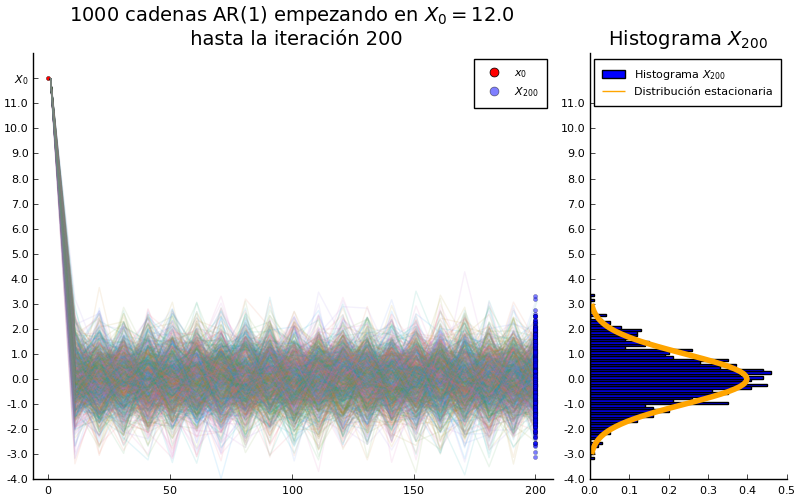

```julia
plot(p1,p2,size=(800,500),layout=l )
```

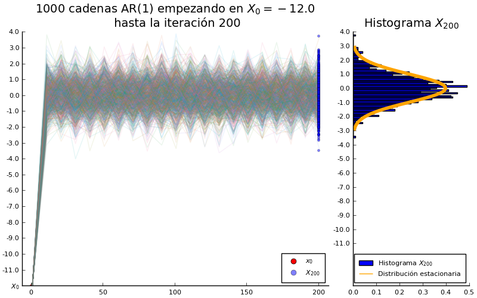

```julia
plot(p1,p2,size=(800,500),layout=l )
```

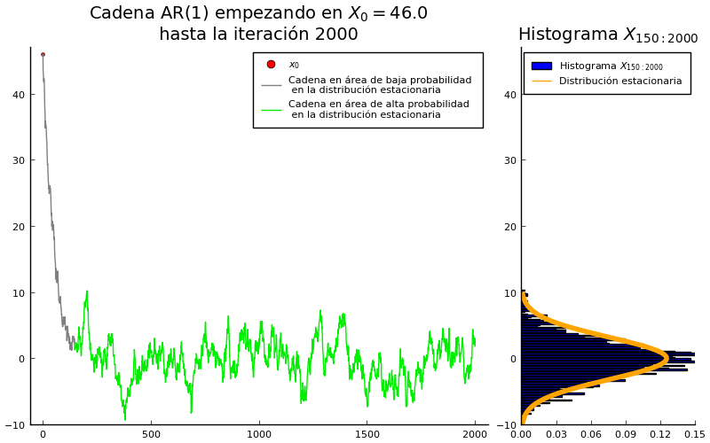

```julia
plot(p1,p2,size=(800,500),layout=l )
```

[figure not shown]

```julia
plot(p)
```

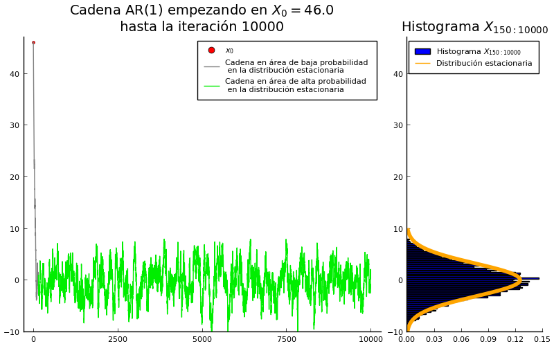

```julia
plot(p1,p2,size=(800,500),layout=l )
```

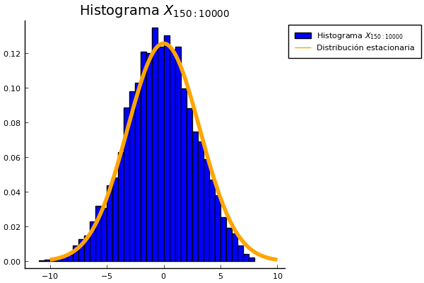

```julia
plot(p)
```

### Reversibilidad

Decimos que una cadena de Márkov $\left\{ X_n \right\}_{n=0}^\infty$ es reversible si la distribución de $X_{n+1}$ condicionada en $X_{n+2}=x$ es igual a la distribución de $X_{n+1}$ condicionada en $X_n=x$.

### Balance detallado

Dado un kernel de transición de probbailidad $P$, decimos que la condición de balance detallado se cumple si existe una función $\pi$ tal que

$$ P(x,y)\pi(x)=P(y,x)\pi(y) $$

Si no hay dificultades con la definición de probabilidades condicionales dadas por el kernel de transición de probbailidad $P$, reversibilidad es equivalente a la condición de balance detallado cuando $\pi$ es una función de densidad de probabilidad.

#### Teorema

Si un kernel de transición de probbailidad $P$ satisface balance detallado con $\pi$ una densida de probabilidad entonces $\pi$ es la densidad invariante de la cadena de Maŕkov asociada a $P$.

Vemos que gracias al teorema anterior una manera de crear cadenas markovianas estacionarias puede consistir de la construcción de cadenas reversibles. El ejemplo más popular de esto es el algoritmo de Metropolis-Hastings

Sea $f_k$ el kernel de una función de densidad de probabilidad y $Q(\pmb{x},\mathrm{d}\pmb{y})\propto q(\pmb{x},\pmb{y})\mathrm{d}\pmb{y}$ un kernel de transición de probabilidad

#### Algoritmo de Metropolis-Hastings

Dado $\pmb{X}_{n-1}$

1) Simule $\pmb{Y}_n\sim \mathcal{L}\left( Q(\pmb{X}), \cdot \right)$ y $U\sim \text{Uniforme}(0,1)$.

2) Acepte $\pmb{X}_n=\pmb{Y}_n$ si se cumple que $$U\leq \alpha(\pmb{X}_{n-1},\pmb{Y}_n) = \min\left\{ 1,\, \frac{f_k(\pmb{Y}_n)q(\pmb{Y}_n,\pmb{X}_{n-1})}{f_k(\pmb{X}_{n-1})q(\pmb{X}_{n-1},\pmb{Y}_n)} \right\};$$ en caso contrario $\pmb{X}_n=\pmb{X}_{n-1}$.

Si $f(\pmb{x})q(\pmb{x},\pmb{y})=0$ entonces por convención, para evitar ambigüedades, definimos $\alpha=1$.

### Proposición

El algoritmo de Metropolis-Hastings genera una cadena de Maŕkov reversible con respecto a $f$.

Observemos que debemos poder generar cadenas con kernel de transición de probabilidad $Q$ aunque para la evaluación del paso de aceptación no es necesario conocer la constante de normalización de la correspondiente distribución condicional. Más áun sólo la evaluación de $f_k$ es necesaria para el paso de aceptación por lo que la constante de normalización de $f$ tampoco debe ser conocida.

### Elecciones de $q$

- #### Metropolis-Hastings simétrico

  Si $q(x,y)=q(y,x)$ entonces la probabilidad de aceptación se reduce a $$\alpha(x,y)=\min\left\{ 1,\, \frac{f_k(y)}{f_k(x)}\right\}$$.
- #### Metropolis-Hastings con caminata aleatoria

  Si $q(x,y)=q(y-x)$. Por ejemplo con $Q(x,\cdot)=\text{Normal}(x,\sigma^2)$ ó con $Q(x,\cdot)=\text{Uniforme}(x-1,x+1)$.
- #### Algoritmo de Langevin

  Si para $\delta>0$ pequeño $$Y_{n+1}\sim\text{Normal}\left(X_n+\frac{\delta}{2} \frac{\mathrm{d}}{\mathrm{d}x}\big( \log(f(x)) \big)\big|_{x=X_n},\, \delta \right)$$

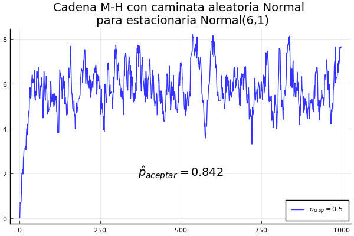

```julia
plot(p1)
```

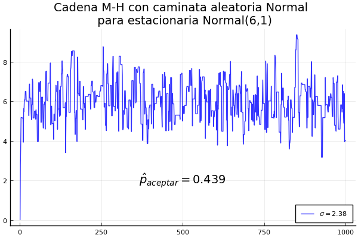

```julia
plot(p2)
```

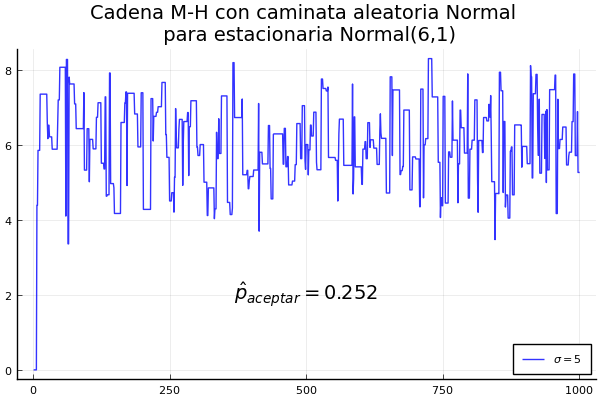

```julia
plot(p3)
```

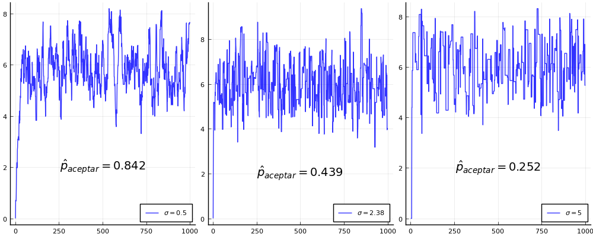

```julia
l = @layout [a  b c]
plot(p1,p2,p3,size=(1000,400),layout=l)
```

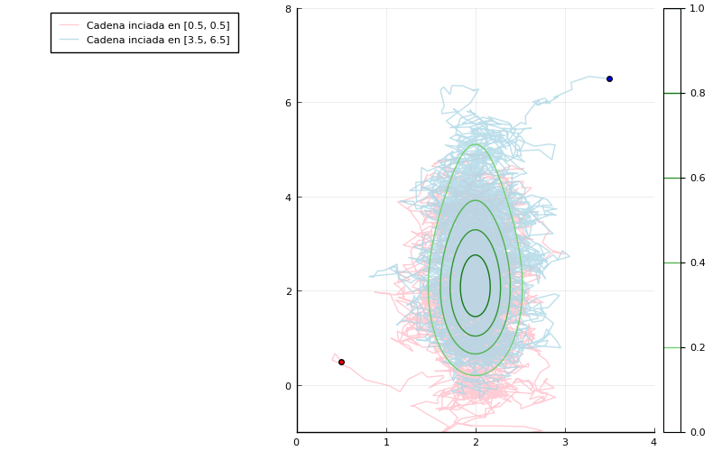

```julia
plot(p,size=(800,500))
```

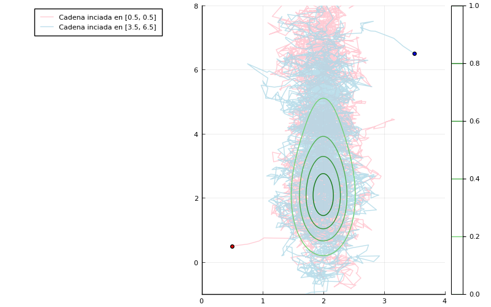

```julia
plot(p,size=(800,500))
```

```
┌ Info: Saved animation to
│   fn = /home/workstation/Documents/Simulacion/metro_anim.gif
└ @ Plots /home/workstation/.julia/packages/Plots/u8HRI/src/animation.jl:104
```

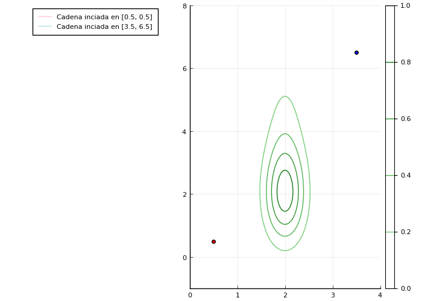

```julia
gif(anim, "metro_anim.gif", fps = 30)
```

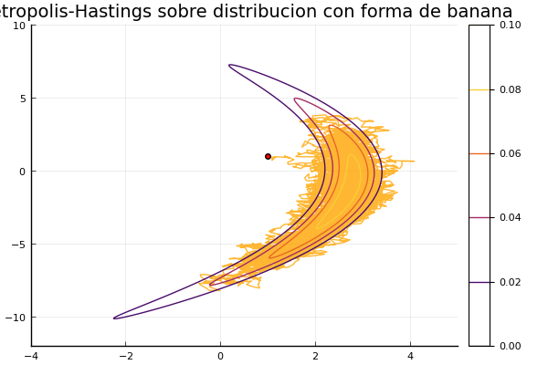

```julia
plot(p)
```

```julia
# Underflow para la Normal
pdf( Normal(), 40)
```

```
0.0
```

```julia
logpdf( Normal(), 40)
```

```
-800.9189385332047
```

Una manera para construir algoritmos de Metropolis-Hastings en cierto subconjunto $I\subset\mathbb{R}$ consiste en considerar el algoritmo de Metropolis-Hastings en $\mathbb{R}$ y una transformación $g\, : \, \mathbb{R}\rightarrow I$ invertible. Por simplicidad consideramos el caso de Metropolis-Hastings con caminata aleatoria gaussiana

$$ \tilde{q}_k(z,w) = e^{-(z-w)^2 /(2\sigma^2)}. $$

Dado $x$ el estado de la cadena proponemos

$$ y=g\left( g^{-1}(x) + \epsilon \right), \quad \text{ con } \epsilon\sim\text{Normal}(0,\sigma^2) $$

con lo que

$$ q_k(x,y) = \tilde{q}_k( g^{-1}(x), \, g^{-1}(y) )\left| \frac{\mathrm{d}}{\mathrm d y}g^{-1}(y) \right|. $$

Observamos que explotando la simetría del kernel $\tilde{q}$

$$ \frac{ q_k(y,x) }{ q_k(x,y) } = \frac{\frac{\mathrm{d}}{\mathrm d x}g^{-1}(x)}{\frac{\mathrm{d}}{\mathrm d y}g^{-1}(y)} $$

\begin{array}{c|c|c|c|c} I & g(x) & g^{-1}(x) & \mathrm{d}g^{-1}(x) & \frac{ q_k(y,x) }{ q_k(x,y) } \\ (0,\infty) & \exp(x) & \log(x) & x^{-1} & \frac{y}{x} \\ (a,\infty) & \exp(x)+a & \log(x-a) & \frac{1}{x-a} & \frac{y-a}{x-a} \\ (-\infty,a) & a-\exp(x) & \log(a-x) & -\frac{1}{a-x} & \frac{y-x}{a-x} \\ [0,1] & \frac{\exp(x)}{\exp(x)+1} & \log\left(\frac{x}{1-x}\right) & \frac{1}{x(1-x)} & \frac{y(1-y)}{x(1-x)} \\ [a,b] & \frac{b\exp(x)+a}{\exp(x)+1} & \log\left(\frac{x-a}{b-x}\right) & \frac{b-a}{(b-x)(x-a)} & \frac{(b-y)(y-a)}{(b-x)(x-a)} \end{array}

## Metropolis-Hastings adaptativo

Dado $\pmb{X}_{n-1},\,\pmb{\mu}_{n-1}$ y $\Gamma_{n-1}$

1) Simule $\pmb{Y}_n\sim N\left( \pmb{\mu}_{n-1}, \, \Gamma_{n-1} \right)$ y $U\sim \text{Uniforme}(0,1)$.

2) Acepte $\pmb{X}_n=\pmb{Y}_n$ si se cumple que $$U\leq \alpha(\pmb{X}_{n-1},\pmb{Y}_n) = \min\left\{ 1,\, \frac{f_k(\pmb{Y}_n)}{f_k(\pmb{X}_{n-1})} \right\};$$ en caso contrario $\pmb{X}_n=\pmb{X}_{n-1}$.

3) Actualice $$\pmb{\mu}_n=\pmb{\mu}_{n-1}+\frac{1}{n}\left( \pmb{X}_n-\pmb{\mu}_{n-1} \right)$$ y $$\Gamma_n=\Gamma_{n-1}+\frac{1}{n}\left( (\pmb{X}_n-\pmb{\mu}_{n-1})(\pmb{X}_n-\pmb{\mu}_{n-1})' - \Gamma_{n-1} \right)$$

### Mezclando cadenas

Si $P_1$ y $P_2$ son kerneles de transición de probabilidad, ambos con distribución estacionaria $f$ entonces la cadena dada por el kernel de transición de probabilidad $P_1P_2$ también tiene distribución estacionaria $f$; por lo que en la práctica es posible mezclar cadenas para generar algoritmos de MCMC.

Observemos que aunque cada $P_1$ y $P_2$ sea reversible para $f$ la cadena de Márkov dada por $P_1P_2$ no será reversible en general. Por esta razón es importante no restringirnos al caso reversible en el estudio de las cadenas de Márkov.

### Muestreo de Gibbs

Sea $\mathcal{X}\subset \mathbb{R}^d$ abierto. El muestreador de Gibbs en la componente $i$, $1\leq i \leq d$ está dado por un kernel de transición de probabilidad que deja las componentes distintas de $i$ iguales y genera la componnete $i$ de la condicional $f_{X_i|X_1=x_1,\ldots , X_{i-1}=x_{i-1},X_{i+1}=x_{i+1},\ldots , X_n=x_n}$, es decir

$$ P_i(\pmb{x}_{\setminus i}, S_{\pmb{x}_{\setminus i},i,a,b} ) = \frac{ \int_a^b f_k(x_1,\ldots , x_{i-1},z,x_{i+1},\ldots , x_n)\mathrm{d}z }{ \int_{-\infty}^\infty f_k(x_1,\ldots , x_{i-1},z,x_{i+1},\ldots , x_n)\mathrm{d}z } $$

con $\pmb{x}_{\setminus i}=(x_1,\ldots, x_{i-1},x_{i+1},\ldots , x_n)$ y $S_{\pmb{x}_{\setminus i},i,a,b}=\left\{ \pmb{y} \in \mathcal{X} \, : \, y_j=x_j \text{ para }j\neq i,\, a\leq y_i \leq b \right\}$.

Construimos los muestreadores de Gibbs al mezclar los kerneles $P_i$.

#### Muestreador de Gibbs con escaneo deterministico

$$P=P_1P_2\cdots P_d$$

#### Muestreador de Gibbs con escaneo aleatorio

$$P=\frac{1}{d}\sum_{i=1}^d P_i$$

### Ejemplo Gaussiano

Consideramos el modelo

\begin{align*} \frac{1}{\sigma^2} & \sim \text{Gamma}(\alpha,\beta) \\ \mu \, | \, \sigma^2 & \sim \text{Normal}\left(\mu_0,\frac{\sigma^2}{\nu}\right) \\ X_i & \sim \text{Normal}\left(\mu,\sigma^2\right),\quad i\in\left\{1,\ldots , n\right\} \end{align*}

Con \begin{align*} \mu_n & = \frac{n\bar{x} +\nu \mu_0}{\nu+n} \\ \nu_n &= \nu + n \\ \alpha_n & =\alpha + \frac{n}{2} \\ \beta_n & = \beta + \frac{1}{2}\sum_{i=1}^n (x_i - \bar{x})^2 + \frac{ \nu n (\bar{x}-\mu_0)^2}{2(\nu+n)} \end{align*}

tenemos que

\begin{equation*} \mu|\sigma^2, X \sim \text{Normal}\left( \mu_n, \frac{\sigma^2}{\nu_n} \right) \end{equation*}

y \begin{equation*} \sigma^2 | \mu, X \sim \Gamma^{-1}\left( \alpha_n + 0.5, \frac{2\beta_n + \nu_n (\mu-\mu_n)^2}{2} \right). \end{equation*}

por lo que podemos implementar un muestreador de Gibbs.

```julia
n = 100
X = rand( Normal( 5.5, 2.2), n); # Varianza es (2.2)²
```

```julia
μ₀ = 3.0
ν = 1.1
α = 4.0
β = 4.5
```

```
4.5
```

```julia
# Entonces μ a priori tiene media media μ₀ y varianza
sqrt(α*ν/β)
```

[output not shown]

```julia
# Por otro lado σ² a priori tiene media
β/(α-1)
```

```
1.5
```

```julia
# y varianza
β^2.0 / ( (α-1)^2.0 * (α-2) )
```

```
1.125
```

```julia
μₙ = ( sum(X) + ν*μ₀ )/( ν + n )
νₙ = ν + n
αₙ = α + 0.5*n
βₙ = β + 0.5*sum( (X .- mean(X) ).^2.0 ) + 0.5*n*ν*(mean(X) - μ₀)^2.0/νₙ ;
```

```julia
# Muestreo de Gibbs
m = 10000 # número de iteraciones para la cadena
chain_μ = zeros(Float64,m+1) # cadena para μ
chain_σ² = zeros(Float64,m+1) # cadena para σ²
chain_μ[1] = rand( Normal(0.0,9.0) ) # incialización aleatoria para μ
chain_σ²[1] = rand( Normal(0.0,4.0) )^2.0 # incialización aleatoria para σ²
for i in 2:(m+1)
    chain_μ[i] = rand( Normal(μₙ,sqrt(chain_σ²[i-1]/νₙ) ) )
    chain_σ²[i] = 1.0/rand( Gamma(αₙ+0.5, 2.0/(2*βₙ+νₙ*(chain_μ[i]-μₙ)^2.0) ) )
end
```

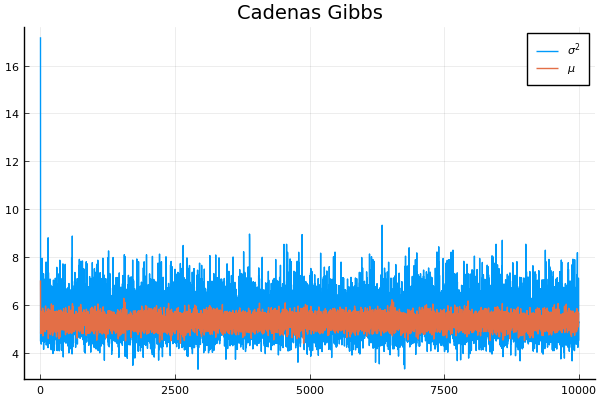

```julia
plot(p)
```

```
┌ Info: Saved animation to
│   fn = /home/workstation/Documents/Simulacion/gibbs_anim.gif
└ @ Plots /home/workstation/.julia/packages/Plots/u8HRI/src/animation.jl:104
```

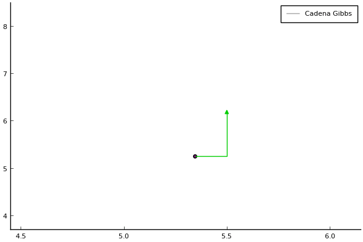

```julia
gif(anim, "gibbs_anim.gif", fps = 2)
```

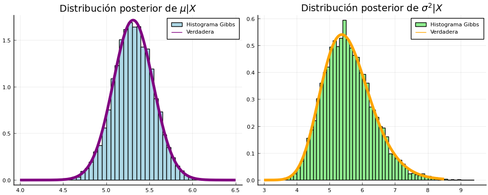

```julia
plot(p1,p2,size=(1000,400))
```

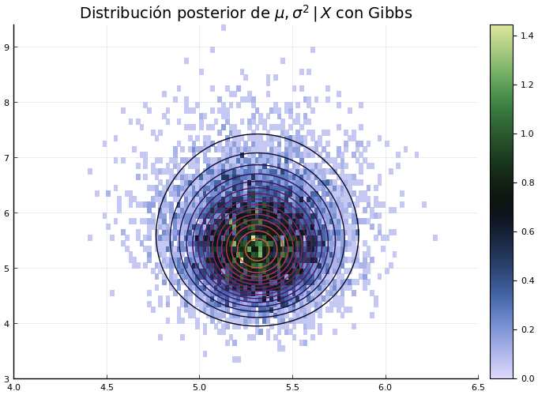

```julia
plot(p,size=(700,500))
```

También podemos hacer un Gibbs por bloque al conocer las posteriores anteriores y las respectivas marginales \begin{equation*} \mu| X \sim t_{2\alpha_n}\left( \cdot \, \Bigg|\mu_n, \frac{\beta_n}{\alpha_n \nu_n} \right) \end{equation*} y \begin{equation*} \sigma^2| X \sim \Gamma^{-1}\left( \alpha_n, \beta_n \right). \end{equation*}

```julia
# Usando directamente la marginal σ² | X y posterior μ | σ², X
m = 10000 # número de iteraciones para la cadena
chain_μ_B2 = zeros(Float64,m) # cadena para μ
chain_σ²_B2 = zeros(Float64,m) # cadena para σ²
for i in 1:m
    chain_σ²_B2[i] = rand( InverseGamma(αₙ,βₙ) )
    chain_μ_B2[i] = rand( Normal(μₙ,sqrt(chain_σ²_B2[i]/νₙ)) )
end
```

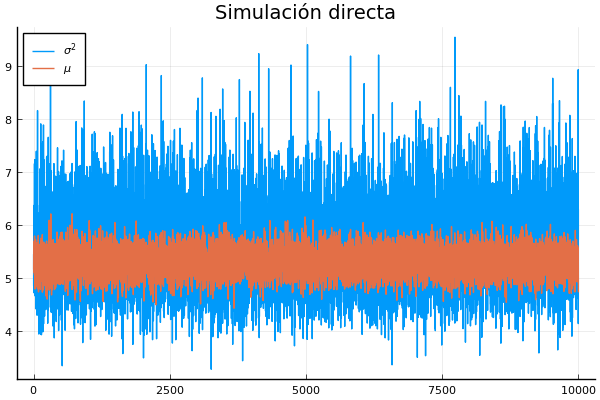

```julia
plot(p)
```

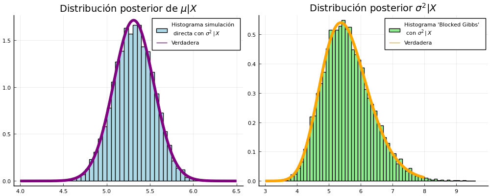

```julia
plot(p1,p2,size=(1000,400))
```

#### Ejemplo Mixtura de Gaussianas

Consideramos el modelo

\begin{align*} \frac{1}{\sigma^2_j} \sim \text{Gamma}&(\alpha,\beta); \quad \mu_j \, | \, \sigma^2_j \sim \text{Normal}\left(\mu_0,\frac{\sigma^2_j}{\nu}\right) ,\quad j\in\left\{1,\ldots , d\right\} \\ \pmb{\Pi} & \sim \text{Dirichlet}\left( \alpha_1,\ldots, \alpha_d \right) \\ \\ Z_i & \sim \text{Categorico}(\pmb{\Pi}),\quad i\in\left\{1,\ldots , n\right\} \\ \\ X_i \, | \, Z_i=j,\, \pmb{\mu},\, \pmb{\sigma^2} & \sim \text{Normal}\left(\mu_j,\sigma^2_j\right),\quad i\in\left\{1,\ldots , n\right\} \end{align*}

Tenemos que

$$ \mathbb{P}\left[ X_i = x \, | \, \pmb{\pi}, \, \pmb{\mu}, \, \pmb{\sigma^2} \right] = \sum_{j=1}^d \pi_j f_{\text{Normal}(\mu_j,\sigma^2_j)}(x) $$

es una mixtura de Gaussianas.

La distribución conjunta está dada por

$$ f(\pmb{X}=\pmb{x},\pmb{z},\pmb{\pi},\pmb{\mu},\pmb{\sigma^2})=\left( \prod_{j=1}^d f_{NIG}(\mu_j,\sigma^2_j) \right) \left( \prod_{i=1}^n f_{\text{Normal}(\mu_{z_i},\sigma^2_{z_i})}(x_i) f_{\pmb{\pi}}(z_i) \right) f_{\text{Dir}(\pmb{\alpha})}(\pmb{\pi}) $$

Observamos que

\begin{align*} f(\pmb{\pi} |\pmb{X}=\pmb{x},\,\pmb{z},\pmb{\mu},\pmb{\sigma^2}) & = f(\pmb{\pi}|\pmb{z}) \\ & \propto f_{\text{Dir}(\pmb{\alpha})}(\pmb{\pi}) \prod_{i=1}^n f_{\pmb{\pi}}(z_i) \\ & \propto \prod_{j=1}^d \pi_j^{\alpha_j -1 } \prod_{i=1}^n f_{\pmb{\pi}}(z_i) \\ & \stackrel{\hat{n}_j=\#(i \, : \, z_i = j)}= \prod_{j=1}^d \pi_j^{\alpha_j + \hat{n}_j -1 } \\ & \propto f_{\text{Dir}(\pmb{\alpha}+\pmb{\hat{n}})}(\pmb{\pi}) \end{align*}

\begin{align*} f( z_i |\pmb{X}=\pmb{x},\,\pmb{\pi},\pmb{\mu},\pmb{\sigma^2}) & = f( z_i | X_i = x_i,\,\pmb{\pi},\pmb{\mu},\pmb{\sigma^2}) \\ & \propto f_{\pmb{\pi}}(z_i)f_{\text{Normal}(\mu_{z_i},\sigma^2_{z_i})}(x_i) \\ & = \pmb{\pi}_{z_i}f_{\text{Normal}(\mu_{z_i},\sigma^2_{z_i})}(x_i) \end{align*}

\begin{align*} f( \mu_j,\, \sigma^2_j |\pmb{X}=\pmb{x},\,\pmb{\pi},\pmb{\mu},\pmb{\sigma^2}) & = f( \mu_i,\, \sigma^2_i | X_i's \, : \, z_i = j ) \end{align*}

```julia
using Distributions, Plots; pyplot();
D = MixtureModel(Normal[ Normal(-3., 1.5), Normal(3.0, 2.5)], [3/5, 2/5])
```

[output not shown]

```
MixtureModel{Normal}(K = 2)
components[1] (prior = 0.6000): Normal{Float64}(μ=-3.0, σ=1.5)
components[2] (prior = 0.4000): Normal{Float64}(μ=3.0, σ=2.5)
```

```julia
X = rand(D,1000);
```

```julia
1.5^2
```

```
2.25
```

```julia
2.5^2
```

```
6.25
```

```julia
μ₀ = 0.0
ν = 2/9
α₀ = 2.5
β₀ = 4.25
```

```
4.25
```

```julia
mean(InverseGamma(α₀,β₀))
```

```
2.8333333333333335
```

```julia
std(InverseGamma(α₀,β₀))
```

```
4.006938426723769
```

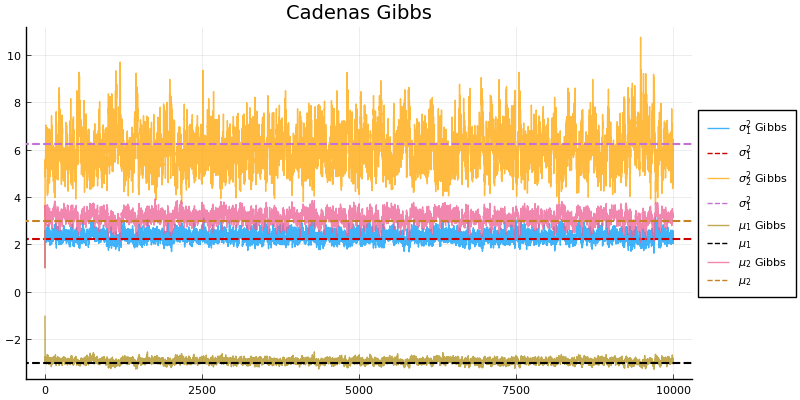

```julia
plot(p,size=(800,400))
```

```julia
mean( [ chain_π[l][1] for l in 1:m] )
```

```
0.618396212986944
```

```julia
mean( [ chain_π[l][2] for l in 1:m])
```

```
0.3815037870130559
```

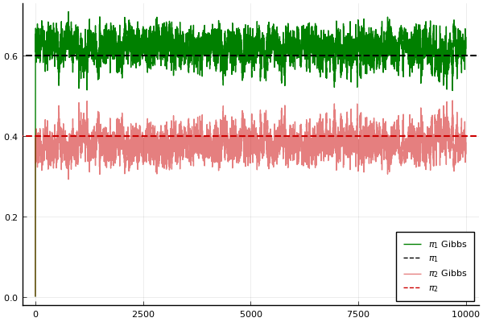

```julia
plot(p)
```

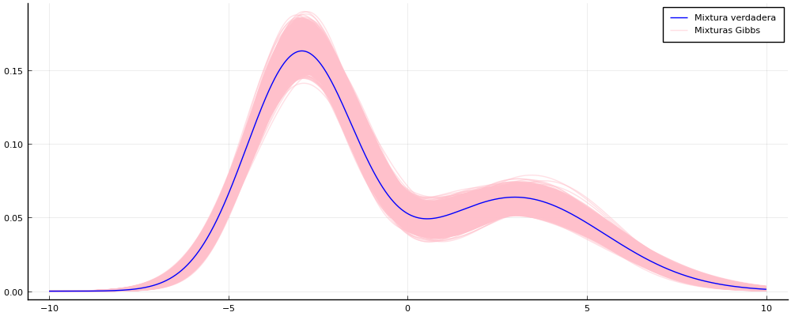

```julia
plot(p, size=(1000,400) )
```

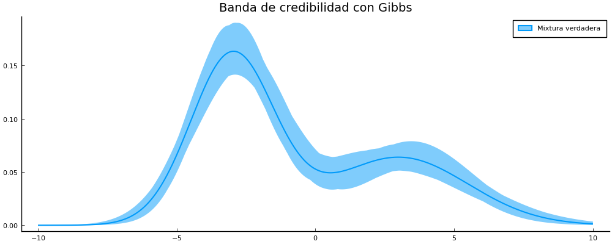

```julia
p=plot( t,  pdf.(D,t), label="Mixtura verdadera", linewidth=1.5, ribbon = (pdf.(D,t) .- mix_band_d, mix_band_u .- pdf.(D,t)), size=(1000,400) , grid=false)
title!("Banda de credibilidad con Gibbs")
```

#### Ejemplo

Regresión Poisson

Supongamos que tenemos muestras $(Y_1,X_1), \ldots , (Y_n,X_n)$ tales que

\begin{align*} Y_i | a,b,X_i & \sim \text{Poisson}\left( e^{aX_i + b} \right) \\ a & \sim \text{Normal}(0,\sigma^2) \\ b & \sim \text{Normal}(0,\tau^2) \end{align*}

Entonces tenemos verosimilitud dada por

\begin{align*} \pi(a,b|\pmb{y},\pmb{x}) &\propto \pi(\pmb{y}|\pmb{x},a,b) \pi(a) \pi(b) \\ & \propto exp\left( a\sum_{i=1}^n y_i + b\sum_{i=1}^n y_i x_i - e^{a}\sum_{i=1}^n e^{x_i b} -\frac{a^2}{2\sigma^2} -\frac{b^2}{2\tau^2} \right) \end{align*}

Entonces

\begin{align*} log\left( \pi(a|\pmb{y},\pmb{x},b) \right) & = a\sum_{i=1}^n y_i - e^{a}\sum_{i=1}^n e^{x_i b} -\frac{a^2}{2\sigma^2} \\ log\left( \pi(b|\pmb{y},\pmb{x},a) \right) & = b\sum_{i=1}^n y_i x_i - e^{a}\sum_{i=1}^n e^{x_i b} -\frac{b^2}{2\tau^2} \end{align*}

y podemos usar aceptación rechazo adaptativo para implementar el muestreador de Gibbs.

#### Definición

La distancia de variación total entre dos medidas de probabilidad $\nu_1$ y $\nu_2$ está dada por

$$ \| \nu_1(\cdot) - \nu_2(\cdot) \| = \sup_A | \nu_1\left(A\right) - \nu_2\left(A\right) | $$

Así las cosas nos podemos preguntar

a) ¿$\lim_{n\to \infty} \| P^n(x,\cdot) - f(\cdot) \| = 0 $?

b) Para $\epsilon > 0$, ¿qué tan grande debe ser $n$ para que $\lim_{n\to \infty} \| P^n(x,\cdot) - f(\cdot) \|<\epsilon $?

#### Proposición

a) $\| \nu_1(\cdot) - \nu_2(\cdot) \|=\sup_{g:\mathcal{X}\rightarrow [0,1]} | \int g \mathrm{d}\nu_1 - \int g \mathrm{d}\nu_2|$

b) Si $f$ es la distribución estacionaria para un kernel de transición de probabilidad $P$ entonces $\forall n \in \mathbb{N}$

$$\|P^n(x,\cdot)-f(\cdot)\|\leq\|P^{n-1}(x,\cdot)-f(\cdot)\|$$

Una cadena de Márkov con distribución estacionaria $f$ puede no converger a $f$. Por ejemplo con $\mathcal{X}=\{1,2,3\}$, f=(1/3,1/3,1/3) y

$$ P = \left( \begin{array} \00.5 & 0.5 & 0 \\ 0.5 & 0.5 & 0 \\ 0 & 0 & 1 \end{array} \right) $$

se tiene $fP=f$ sin embargo si $X_0=1$ entonces $X_n\in\{1,2\}\; \forall n\geq 1$ con lo que $\mathbb{P}[X_n=3]=0\neq \frac{1}{3}=f(\{3\})$. De hecho en este caso la distribución estacionaria no es única y se está convergiendo a la estacionaria $f_2=(0.5,0.5,0)$.

#### Definición

Una cadena de Márkov es $\phi$-irreducible si existe una medida $\phi$ distinta de cero, $\sigma$-finita en $\mathcal{X}$ tal que para todo $A\subset \mathcal{X}$ tal que $\phi(A)>0$ y $x\in\mathcal{X}$ se tiene que existe $n=n(x,A)\in \mathbb{N}\setminus \{0\}$ que satisface

$$ P^n (x,A)> 0. $$

Por ejemplo, para el algoritmo de Metropolis-Hastings con distribución estacionaria dada por una densidad de probabilidad $f$ finita en $\mathcal{X}$, y kernel de transición $Q$ auxiliar con una densidad $q(\cdot,\cdot)$ positiva y continua en $\mathbb{R}^d\times \mathbb{R}^d$ se tiene que la cadena de Márkov asociada al algoritmo es $f$-irreducible.

Sea $A$ tal que $f(A)>0$ entonces $\exists \, r> 0$ tal que $A_r=A\cap B_r(0)$, con $B_r(\pmb{0})$ la bola con radio $r$ centrada en $\pmb{0}$, satisface $f(A_r)>0$. Por continuidad de $q$ para cualquier $\pmb{x}\in \mathbb{R}^d$

$$ \inf_{\pmb{y}\in A_r}\min\{ q(\pmb{x},\pmb{y}),\, q(\pmb{y},\pmb{x}) \}\geq \epsilon $$

para algún $\epsilon >0$. En el caso $f(x)=0$ tenemos por convención que $\alpha=1$ por lo que siempre aceptamos y tenemos $P(\pmb{x},A)=Q(\pmb{x},A)>0$. Nos enfocamos entonces en $\pmb{x}$ tal que $f(\pmb{x})>0$ con lo que

\begin{align*} P(x,A) & \geq P(x,A_r) \geq \int_{A_r} q(\pmb{x},\pmb{y})\min \left\{ 1, \, \frac{f(\pmb{y})q(\pmb{y},\pmb{x})}{ f(\pmb{x})q(\pmb{x},\pmb{y})} \right\}\mathrm{d}\pmb{y} = \int_{A_r} \min \left\{ \frac{ f(\pmb{x})q(\pmb{x},\pmb{y})}{f(\pmb{x})}, \, \frac{f(\pmb{y})q(\pmb{y},\pmb{x})}{ f(\pmb{x})} \right\}\mathrm{d}\pmb{y} \\ & \geq \epsilon \, \big| \left\{ \pmb{y}\in A_r \, : \, f(\pmb{y}) \geq f(\pmb{x}) \right\} \big| + \frac{ \epsilon }{f(\pmb{x})} f\left( \left\{ \pmb{y}\in A_r \, : \, f(\pmb{y}) < f(\pmb{x}) \right\} \right) \end{align*}

donde $|C|$ denota el área o medida de Lebesgue del conjunto $C$. Si ambos términos en la última igualdad son cero entonces $f\equiv 0$ lo cual es una contradicción. Se concluye que $P(x,A)>0$ y la cadena de Métropolis-Hastings es $f$-irreducible.

Incluso cadenas $\phi$-irreducibles pueden no converger en distribución debido a problemas de periodicidad. Por ejemplo si consideramos $\mathcal{X}=\{1,2,3\}$, f=(1/3,1/3,1/3) y

$$ P = \left( \begin{array} 00 & 1 & 0 \\ 0 & 0 & 1 \\ 1 & 0 & 0 \end{array} \right) $$

entonces la cadena es $\phi$-irreducible para cualquier medida $\phi$ y el límite de $\mathbb{P}[X_n=1]$ conforme $n\to \infty$ no existe por lo que no puede haber estacionariedad.

#### Definición

Una cadena de Maŕkov con distribución estacionaria $f$ es aperiódica si no existe $d\geq 2$ y subconjuntos disjuntos $\mathcal{X}_1,\mathcal{X}_2,\ldots , \mathcal{X}_d\subset \mathcal{X}$ con $P(x,\mathcal{X}_{i+1})=1\, \forall \, x\in\mathcal{X}_i, \, i\in\{1,2,\cdots ,d-1\},$ y $P(x,\mathcal{X}_1)=1 \, \forall \, x\in\mathcal{X}_d$ tal que $f(\mathcal{X}_1)>0$, y en consecuencia $f(\mathcal{X}_i)>0$ para $i\in\{ 2,\ldots , d \}$.

Por ejemplo la cadena de Metropolis-Hastings con las condiciones anteriores es aperiódica. Para ver esto, supongamos lo contrario, si $\mathcal{X}_1$ y $\mathcal{X}_2$ son disjuntos y tales que $P(\pmb{x},\mathcal{X}_2)=1 \, \forall \pmb{x}\in \mathcal{X}_1$ entonces para $ \pmb{x}\in \mathcal{X}_1$ fijo

$$ P(\pmb{x},\mathcal{X}_1)\geq \int_{\pmb{y}\in \mathcal{X}_1} q(\pmb{x},\pmb{y})\alpha(\pmb{x},\pmb{y})\mathrm{d}\pmb{y}>0 $$

lo cual da una contradicción. (Recuerde que si $f(\pmb{x})=0$ entonces $\alpha(\pmb{x},\pmb{y})=1$ por convención).

#### Teorema convergencia en variación total

Una cadena de Márkov (con un espacio de estados cuya $\sigma$-álgebra es generada con una familia numerable de conjuntos) aperiódica y $\phi$-irreducible con distribución estacionaria $f$ satisface

$$ \lim_{n \to \infty}\| P^n(x,\cdot) -f(\cdot) \|=0 $$

(para $f$-casi-todo $\pmb{x}\in\mathcal{X}$).

En particular $\lim_{n \to \infty}P^n(x,A)=f(A) \, \forall A\subset \mathcal{B}(\mathcal{X})$.

#### Teorema ergódico

Aún más con las condiciones anteriores, si $h\, : \, \mathcal{X} \rightarrow \mathbb{R}$ es tal que $\int_{\mathcal{X}} |h(\pmb{x})|f(\pmb{x})\mathrm{d}\pmb{x}=f(|h|)<\infty$ entonces se tiene una ley fuerte de los grandes números para la cadena de Márkov $\left\{ X_i \right\}_{i=0}^\infty$:

$$ \lim_{n\to \infty} \frac{1}{n}\sum_{i=1}^n h(\pmb{X}_i) \stackrel{\text{c.s.}}{=}\int_{\mathcal{X}} h(\pmb{x})f(\pmb{x})\mathrm{d}\pmb{x} = \mathbb{E}_f[\pmb{X}]. $$

#### Definición

Una cadena de Márkov con distribución estacionaria $f$ es uniformemente ergódica si

$$ \| P^n(\pmb{x},\cdot) -f(\cdot) \| \leq M \rho^n, \quad n\in\left\{1,2,\ldots\right\} $$

para $\rho < 1$ y $M<\infty$.

Para dar condiciones que aseguren ergodicidad uniforme utilizamos el siguiente concepto.

#### Definición

Decimos que un conjunto $C$ es pequeño, o $(n_0,\epsilon,\nu)$-pequeño, si $\exists$ un entero positivo $n_0$, real positivo $\epsilon>0$ y una medida de probabilidad $\nu$ en $\mathcal{X}$ tales que

$$ P^{n_0}(\pmb{x},A)\geq \epsilon \nu(A), \quad \forall \pmb{x} \in C, \, A\in\mathcal{B}(\mathcal{X}). $$

Por ejemplo para la cadena de Metropolis-Hastings con las condiciones anteriores los conjuntos compactos donde $f$ es acotada son pequeños. Sea $C$ un conjunto compacto tal que $f|_{C}\leq k < \infty$. Sea $\pmb{x}\in C$, $A$ un conjunto y $A_r$ subconjunto de $A$ compacto tal que $f(A_r)>0$; definimos

$$ \epsilon= \inf_{\pmb{x}\in C,\, \pmb{y}\in A_r} \min\left\{ q(\pmb{x},\pmb{y}),q(\pmb{y},\pmb{x}) \right\} >0. $$

entonces

$$ P(\pmb{x},\mathrm{d}\pmb{y})\geq q(\pmb{x},\pmb{y})\min\left\{ 1, \frac{q(\pmb{y},\pmb{x})f(\pmb{x})}{q(\pmb{x},\pmb{y}f(\pmb{y}))} \right\} \mathrm{d}\pmb{y} = \min \left\{ q(\pmb{x},\pmb{y}), \, \frac{f(\pmb{y})q(\pmb{y},\pmb{x})}{ f(\pmb{x})} \right\}\mathrm{d}\pmb{y} \geq \epsilon \min \left\{ 1, \, \frac{f(\pmb{y})}{ k } \right\}\mathrm{d}\pmb{y}>0 $$

Por lo que $C$ es pequeño. En particular si $\mathcal{X}$ es compacto entonces $\mathcal{X}$ es pequeño.

#### Teorema ergodicidad uniforme para espacio de estados pequeño

Dada una cadena de Márkov con distribución de probabilidad estacionaria $f$ y espacio de estados $\mathcal{X}$ pequeño respecto a algunos $n_0,\epsilon >0$ y medida de probabilidad $\nu$. Entonces la cadena es uniformemente ergódica, de hecho

$$ \lim_{n\to \infty}\| P^n(x,\cdot) -f(\cdot) \|\leq (1-\epsilon)^{\lfloor n/n_0 \rfloor} $$

#### Definición

Una cadena de Márkov con distribución estacionaria $f$ es geométricamente ergódica si

$$ \| P^n(x,\cdot) -f(\cdot) \| \leq M(x) \rho^n, \quad n\in\left\{1,2,\ldots\right\}, $$

para $\rho < 1$ y $M(x)<\infty$ para ($f$-casi-todo) $x\in \mathcal{X}$.

#### Pruebas de convergencia usando construcciones de couplings (acoplamientos)

Sean $X$ y $Y$ variables aleatorias en algún espacio $\mathcal{X}$, entonces

\begin{align*} \| \mathcal{L}(X) - \mathcal{L}(Y) \| &= \sup_A | \, \mathbb{P}[X\in A] - \mathbb{P}[Y\in A] \, | \\ & = \sup_A | \, \mathbb{P}[X\in A,\, X=Y] + \mathbb{P}[X\in A,\, X \neq Y] \\ & \hphantom{==} - \mathbb{P}[Y\in A,\, X=Y] - \mathbb{P}[Y\in A,\, X \neq Y] \, | \\ & = \sup_A | \, \mathbb{P}[X\in A,\, X \neq Y] + \mathbb{P}[Y\in A,\, X \neq Y] \\ & \leq \mathbb{P}[X \neq Y ] \end{align*}

Llamamos a

$$ \| \mathcal{L}(X) - \mathcal{L}(Y) \| \leq \mathbb{P}[X \neq Y ] $$

la desigualdad de coupling (o acoplamiento).

### Algoritmo para construcción de un coupling

Sea $X_0=x$, $X_0'\sim \mathcal{L}(f)$ y $P$ un kernel de transición de probabilidad que define una cadena de Márkov con $C$ un conjunto $(n_0,\epsilon,\nu)$-pequeño.

Para $n\in\left\{1,2,\ldots\right\}$ realice

1) Si $X_n=X_n'$ elija $X_{n+1}=X_{n+1}'\sim P(X_n,\cdot)$

2) En caso contrario, si $(X_n,X_n')\in C\times C$ entonces con probabilidad \$\epsilon\$ tome $$X_{n+n_0}=X_{n+n_0}'\sim \nu(\cdot)$$ y con probabilidad $1-\epsilon$ tome \begin{align*}X_{n+n_0} & \sim \frac{1}{1-\epsilon}\bigg( P^{n_0}(X_n,\cdot)-\epsilon \nu(\cdot) \bigg) \\ X_{n+n_0}' & \sim \frac{1}{1-\epsilon}\bigg( P^{n_0}(X_n',\cdot)-\epsilon \nu(\cdot) \bigg). \end{align*} Si $n_0>1$ tome $X_{n+1},\ldots , X_{n+n_0-1}|X_n, X_{n+n_0}$ y, condicionalmente independientes, $X_{n+1}',\ldots , X_{n+n_0-1}'|X_n', X_{n+n_0}'$.

3) En caso contrario, de forma condicionalmente indpendiente, tome \begin{align*}X_{n+1} & \sim P(X_n,\cdot) \\ X_{n+1}' & \sim P(X_n',\cdot). \end{align*}

Observemos que si $X_n\neq X_n'$, para lo cual decimos que el coupling no se ha acoplado, entonces la ley de probabilidad para $X_{n+1}|X_n$ es $P(X_n,\cdot)$ pues en caso de que $(X_n,X_n')\in C \times C$

$$ \epsilon \nu(\cdot) + (1-\epsilon)\frac{1}{1-\epsilon}\bigg( P^{n_0}(X_n,\cdot)-\epsilon \nu(\cdot) \bigg) =P^{n_0}(X_n,\cdot) $$

y $X_{n+1},\ldots , X_{n+n_0-1}$ son generados por las distribuciones condicionales adecuadas. Análogamente $X_{n+1}'|X_n'$ tiene distribución dada por $P(X_n',\cdot)$ y al tener $X_0'\sim \mathcal{L}(f)$ se sigue que $X_n'\sim\mathcal{L}(f) \, \forall n\geq 1$.

#### Demostración del teorema de ergodicidad uniforme para espacio de estados pequeño

Sea una cadena de Márkov con distribución de probabilidad estacionaria $f$ y espacio de estados $\mathcal{X}$ pequeño respecto a algunos $n_0,\epsilon >0$ y medida de probabilidad $\nu$. Entonces para la construcción del coupling asociado hay probabilidad $\epsilon$ cada $n_0$ iteraciones del coupling para que $X_n=X_n'$, en particular si $n=m n_0$ por la desigualdad de coupling tenemos

$$ \lim_{n\to \infty }\| \mathcal{L}(X_n) - \mathcal{L}(X_n') \| = \lim_{n\to \infty }\| P^n(x,\cdot) - f(\cdot) \| \leq \mathbb{P}[X_n \neq X_n' ] \leq (1-\epsilon)^m = (1-\epsilon)^{n/n_0}. $$

En vista de nuestros ejemplos particulares del algoritmo de Metropolis-Hastings consideramos $n_0=1$ para el conjunto pequeño $C$ y el coupling más sencillo

$X_0=x$, $X_0'\sim \mathcal{L}(f)$ y para $n\in\left\{1,2,\ldots\right\}$ realice

1) Si $X_n=X_n'$ tome $X_{n+1}=X_{n+1}'\sim P(X_n,\cdot)$

2) En caso contrario, si $(X_n,X_n')\in C\times C$ entonces con probabilidad \$\epsilon\$ tome $$X_{n+1}=X_{n+1}'\sim \nu(\cdot)$$ y con probabilidad $1-\epsilon$ tome \begin{align*}X_{n+1} & \sim \frac{1}{1-\epsilon}\bigg( P(X_n,\cdot)-\epsilon \nu(\cdot) \bigg) \\ X_{n+1}' & \sim \frac{1}{1-\epsilon}\bigg( P(X_n',\cdot)-\epsilon \nu(\cdot) \bigg). \end{align*}

3) En caso contrario, de forma condicionalmente indpendiente, tome \begin{align*}X_{n+1} & \sim P(X_n,\cdot) \\ X_{n+1}' & \sim P(X_n',\cdot). \end{align*}

El teorema de convergencia en variación total no hace supuestos sobre la existencia de un conjunto pequeño para poder construir un copling por lo que para su demostración hacemos uso del siguiente teorema técnico.

#### Teorema de existencia de un conjunto pequeño

Toda cadena de Márkov $\phi$-irreducible (en un espacio de estados con $\sigma$-álgebra generada contablemente), tiene un conjunto pequeño $C\subset \mathcal{X}$ tal que $\phi(C)>0$ y $\nu(C)>0$.

#### Lema técnico

Sea una cadena de Márkov $\phi$-irreducible y aperiódica en $\mathcal{X}$ y $A\subset \mathcal{X}$ (medible) si $\mathbb{P}_{\pmb{x}}[\tau_A<\infty]>0\; \forall \, \pmb{x}\in\mathcal{X}$, entonces $\mathbb{P}_{\pmb{x}}[\tau_A<\infty]=1$ para $f$-casi-todo $\pmb{x}\in\mathcal{X}$.

Donde recordamos que

$$ \tau_A = \inf\left\{ n \geq 1 \, : \, X_n\in A \right\}. $$

#### Demostración teorema convergencia en variación total

Por el teorema de existencia de un conjunto pequeño sea $C$ pequeño tal que $\phi(C),\nu(C)>0$. Construimos el coupling asociado para $C$ y consideramos la cadena de Márkov $\left\{ X_i,X_i' \right\}_{i=1}^\infty$. Sea $G=\left\{ (x,x') \, : \, \mathbb{P}_{(x,x')}\left[ \exists \, n\geq 1 \, : \, X_n=X'_n \right]=1 \right\}\subset\mathcal{X}\times \mathcal{X}$. Si $(X_0,X_0')=(x,X_0')\in G$ entonces usando la desigualdad de coupling como en la prueba del teorema de ergodicidad uniforme obtenemos

$$ \lim_{n\to \infty }\| P^n(x,\cdot) - f(\cdot) \| = 0 $$

Por lo que basta ver que para $f$-casi-todo $x\in\mathcal{X}$ $\mathbb{P}[(x,X_0')\in G]=1$.

Tenemos que $\phi(C)>0$ por lo que de la definición de $\phi$-irreducibilidad $\forall x \in\mathcal{X}$ hay un $ñ$ tal que $P^ñ(x,C)>0$, por otro lado $f(C)>0$ por lo que desde cualquier $(x,x')\in\mathcal{X}\times \mathcal{X}$ la cadena tiene probabilidad positiva de alcanzar $C\times C$ ya que por la construcción del coupling $\mathbb{P}[(X_ñ,X_ñ)\in C\times C|(X_0=x,X_0')]\geq P^ñ(x,C)f(C)^ñ$, del lema técnico anterior se sigue que para $f$-casi-todo $x\in\mathcal{X}$ la cadena del coupling vistia $C\times C$ con probabilidad 1. En ese momento la cadena se acopla con probabilidad $\epsilon$ y en caso contrario toma valores en un cojunto donde $f$ integra positivo (al ser f invariante para P $\phi$-irreducible $P(x,\cdot)<< f \, \forall x \in \mathcal{X}$ de lo cual se sigue de la definición de conjunto pequeño que $\nu << f$) por lo que se puede aplicar el lema técnico nuevamente para ver que con probabilidad 1 se regresa nuevamente a $C\times C$ nuevamente con probabilidad $\epsilon$ de acoplarse. Se sigue que $ \mathbb{P}_{(x,X_0')}\left[ \exists \, n\geq 1 \, : \, X_n=X'_n \right]=1$ por lo que $(x,X_0')\in G$.

Para la demostración del teorema ergódico haremos uso de la siguiente definición.

#### Definición

Un tiempo de regeneración es un tiempo de paro $\tau$ con la propiedad de que $(X_\tau,X_{\tau +1},\ldots)\perp (X_{\tau - 1}, X_{\tau -2})$.

### Algoritmo para splitting (partimiento) de una cadena de Márkov

Sea $X_0=x$ y $P$ un kernel de transición de probabilidad que define una cadena de Márkov con $C$ un conjunto $(n_0=1,\epsilon,\nu)$-pequeño.

Para $n\in\left\{1,2,\ldots\right\}$ realice

1) Si $X_n\in C$ entonces con probabilidad \$\epsilon\$ tome $$X_{n+1}\sim \nu(\cdot)$$ y con probabilidad $1-\epsilon$ tome \begin{align*}X_{n+1} & \sim \frac{1}{1-\epsilon}\bigg( P(X_n,\cdot)-\epsilon \nu(\cdot) \bigg) \end{align*}

En la construcción anterior decimos que la cadena se parte en $X_n$ o al tiempo $n$ si $X_n\in C$ y $X_{n+1}$ es generada con la distribución de probabilidad $\nu(\cdot)$. Observemos que los tiempos de partimiento son tiempos de regeneración por construcción y que para cualquier $n\geq 1$ la distribución marginal de $X_n$ está dada por

$$ \epsilon \nu(\cdot) + (1-\epsilon)\frac{1}{1-\epsilon}\bigg( P(X_n,\cdot)-\epsilon \nu(\cdot) \bigg) = P(X_n,\cdot). $$

Sea $\tau_0=0$ y

$$ \tau_j = \inf\left\{ n> \tau_{j-1} \, : \, X_{n-1}\in C, \, X_{n}\sim\nu(\cdot) \right\} $$

#### Demostración del teorema ergódico

Demostraremos algo un poco más fuerte. Sea $h,g$ integrables en valor absoluto respecto a $f$. Demostraremos que

$$ \lim_{n\to \infty} \frac{\sum_{i=1}^nh(X_i)}{\sum_{i=1}^n g(X_i)}\stackrel{\text{c.s.}}{\longrightarrow} \frac{\int h(x)f(x)\mathrm{d}x}{\int g(x)f(x)\mathrm{d}x} $$

Sea $K_n+1$ el número de veces que el splitting se ha partido hasta el tiempo $n$, observemos que procediendo como en la prueba del teorema para la variación total $K_n\stackrel{\text{c.s.}}{\rightarrow}\infty$, que tenemos las siguientes desigualdades

\begin{align*} \sum_{j=0}^{K_n} \sum_{i=\tau_j +1}^{\tau_{j+1}} f(X_i) & \leq \sum_{i=1}^n f(X_i) \leq \sum_{j=0}^{K_n+1} \sum_{i=\tau_j +1}^{\tau_{j+1}} f(X_i) \end{align*}

y que las variables aleatorias

$$ S_j(f) = \sum_{i=\tau_j +1}^{\tau_{j+1}} f(X_i) $$

son independientes e idénticamente didtribuidas.

Se sigue que

$$ \frac{K_n + 1}{K_n+2} \frac{ \frac{1}{K_n+1}\sum_{j=0}^{K_n} S_j(h) }{ \frac{1}{K_n+2}\sum_{j=0}^{K_n+1} S_j(g) } \leq \frac{\sum_{i=1}^n h(X_i)}{\sum_{i=1}^n g(X_i)} \leq \frac{K_n + 2}{K_n+1} \frac{ \frac{1}{K_n+2}\sum_{j=0}^{K_n+1} S_j(h) }{ \frac{1}{K_n+1}\sum_{j=0}^{K_n} S_j(g) } $$

Por lo que utilizando la Ley de los Grandes números usual para los bloques $S_j$ y el hecho de que $\frac{K_n + 2}{K_n+1}\stackrel{\text{c.s.}}{\longrightarrow}1$ y el teorema de Slutsky (o del mapeo continuo) se sigue que

$$ \lim_{n\to \infty} \frac{\sum_{i=1}^nh(X_i)}{\sum_{i=1}^n g(X_i)}\stackrel{\text{c.s.}}{=} \frac{\int h(x)f(x)\mathrm{d}x}{\int g(x)f(x)\mathrm{d}x} $$

#### Definición

Una cadena de Márkov tiene un átomo $\alpha\in\mathcal{B}(\mathcal{X})$ si

$$ P(x,A)=\nu(A),\quad \forall x\in\alpha, \, \forall A\in\mathcal{B}(\mathcal{X}) $$

Sea $\alpha$ un átomo de una cadena de Márkov y

$$ \tilde{\pi}(A)=\mathbb{E}_{\alpha}\left[ \sum_{i=0}^{\tau_\alpha-1} \pmb{1}\left\{ X_i \in A \right\} \right] $$

Tenemos que \begin{align*} \tilde{\pi}(A) & = \pmb{1}\left\{ X_0 \in \alpha, \, X_0 \in A \right\} + \sum_{i=1}^{\infty} \mathbb{E}_{\alpha}\left[ \pmb{1}\left\{ X_i \in A, \, \tau_\alpha >i \right\} \right] \\ & = \mathbb{E}[ \pmb{1}\left\{ X_0 \in \alpha, \, X_0 \in A \right\} ]+ \sum_{i=1}^{\infty} \mathbb{E}_{\alpha}\left[ \pmb{1}\left\{ X_i \in A, \, \tau_\alpha >i-1 \right\} \right] -\sum_{i=1}^{\infty} \mathbb{E}_{\alpha}\left[ \pmb{1}\left\{ X_i \in A, \, \tau_\alpha = i \right\} \right] \\ & = \mathbb{E}[ \pmb{1}\left\{ X_0 \in \alpha, \, X_0 \in A \right\} ] + \mathbb{E}_{\alpha}\left[ \sum_{i=1}^{\infty} \pmb{1}\left\{ X_i \in A, \, \tau_\alpha >i-1 \right\} \right] -\sum_{i=1}^{\infty} \mathbb{E}_{\alpha}\left[ \pmb{1}\left\{ X_i \in A, \, \tau_\alpha = i \right\} \right] \end{align*}

\begin{align*} & = \mathbb{E}[\pmb{1}\left\{ X_0 \in \alpha, \, X_0 \in A \right\} ]+ \mathbb{E}_{\alpha}\left[ \sum_{i=1}^{\infty} P(X_{i-1},A) \pmb{1}\left\{ \, \tau_\alpha >i-1 \right\} \right] -\mathbb{E}_{\alpha}\left[ \pmb{1}\left\{ X_{\tau_\alpha} \in A \right\} \right] \\ & = \mathbb{E}[\pmb{1}\left\{ X_0 \in \alpha, \, X_0 \in A \right\} ]+ \mathbb{E}_{\alpha}\left[ \sum_{i=1}^{\infty} P(X_{i-1},A) \pmb{1}\left\{ \, \tau_\alpha >i-1 \right\} \right]-\mathbb{E}[ \pmb{1}\left\{ X_0 \in \alpha, \, X_0 \in A \right\} ] \\ & = \mathbb{E}_{\alpha}\left[ \sum_{i=1}^{\infty} P(X_{i-1},A) \pmb{1}\left\{ \, \tau_\alpha >i-1 \right\} \right] = \mathbb{E}_{\alpha}\left[ \sum_{i=1}^{\tau_\alpha} P(X_{i-1},A) \right]= \mathbb{E}_{\alpha}\left[ \sum_{i=0}^{\tau_\alpha -1} P(X_{i},A) \right]= \int \tilde{\pi}(\mathrm{d}x)P(x,A) \end{align*}

### Teorema de límite central para cadenas de Márkov

#### Definición

Para una cadena de Márkov $\phi$-irreducible y aperiódica con distribución estacionaria $f$, decimos que $h\, : \, \mathcal{X}\rightarrow \mathbb{R}$ satisface un teorema del límite central (TLC) si al ser iniciada la cadena en estacionariedad, es decir $X_0\sim\mathcal{L}(f)$ entonces

$$ \frac{1}{\sqrt{n}}\sum_{i=1}^n \left( h(X_i) - f(h) \right)=\frac{1}{\sqrt{n}}\sum_{i=1}^n \left( h(X_i) - \int h(x)f(x)\mathrm{d}x \right)\stackrel{d}{\rightarrow}N(0,\sigma^2) $$

con

$$ \sigma^2 = \lim_{n\to \infty} \frac{1}{n}\mathbb{E}\left[ \left( \sum_{i=1}^n \left( h(X_i) - f(h) \right) \right)^2 \right] $$

#### Teorema

Sea una cadena de Márkov reversible inciada en estacionariedad y $r(x)=\mathbb{P}\left[ X_{n+1}=X_n|X_n=x \right]$. Si

$$ \lim_{n\to \infty} nf\left( (h-f(h))^2r^n \right)=\infty $$

entonces no se satisface un TLC para $h$.

\begin{align*} \sigma^2 = \lim_{n\to \infty} \frac{1}{n}\mathbb{E}\left[ \left( \sum_{i=1}^n \left( h(X_i) - f(h) \right) \right)^2 \right] \geq \lim_{n\to \infty} \frac{1}{n}\mathbb{E}\left[ \left( \sum_{i=1}^n \left( h(X_i) - f(h) \right) \right)^2 \pmb{1}\left\{ X_0 = X_1=\ldots = X_n \right\} \right] \\ = \frac{1}{n}\mathbb{E}\left[ n \left( h(X_0) - f(h) \right)^2 r(X_0)^n \right] =\lim_{n\to \infty} nf\left( (h-f(h))^2r^n \right)=\infty \end{align*}

#### Teorema

Si una cadena de Márkov con distribución estacionaria $f$ es uniformemente ergódica entonces se sastiface un TLC para $h$ tal que $f(h^2)<\infty$

#### Teorema

Si una cadena de Márkov con distribución estacionaria $f$ es geométricamente ergódica entonces se sastiface un TLC para $h$ tal que $f(|h|^{2+\delta})<\infty$ para algún $\delta>0$.

#### Teorema

Si una cadena de Márkov con distribución estacionaria $f$ es geométricamente ergódica y reversible entonces se sastiface un TLC para $h$ tal que $f(h^2)<\infty$

#### Teorema

Si una cadena de Márkov es $\phi$-irreducible, aperiódica y reversible con distribución estacionaria $f$ entonces se sastiface un TLC cuando $\sigma^2 <\infty$.